# 09_subj-ratings_analysis

Overall: 72 participants

## Additional Info

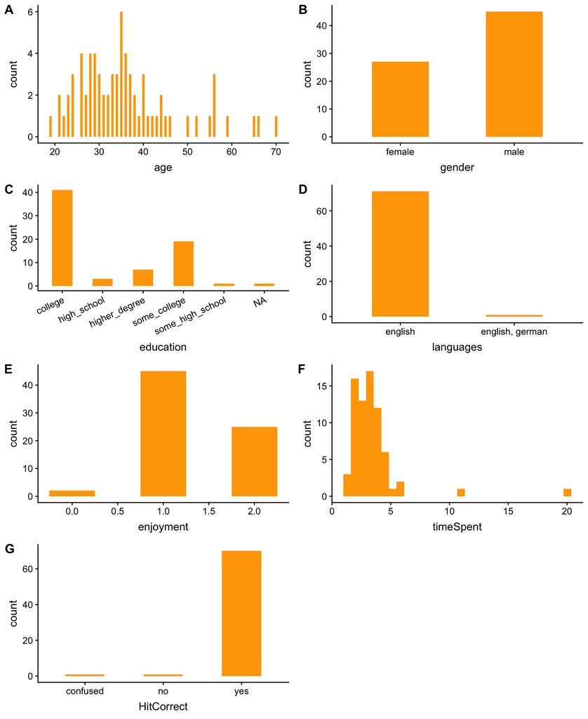

This looks good, I think.

## Correlation between questions

I excluded all participants who rated more than 2 of the control questions wrong (i.e., participants who answered them correctly or clicked “Doesn’t apply” are kept.)  
For the computation of the correlation, I used Pearson.  
I have thought about applying PCA (as Judith and I had discussed), but I don’t see how this helps me selecting the questions. From my understanding, PCA creates orthogonal eigenvectors which are linear combinations of the original variables to achieve a more accurate representation of the data. One can then compute the correlation with the original variables, but I don’t see why this would help us any more than just looking at the correlations and choose one out of the two that highly correlate. Do I miss something here?

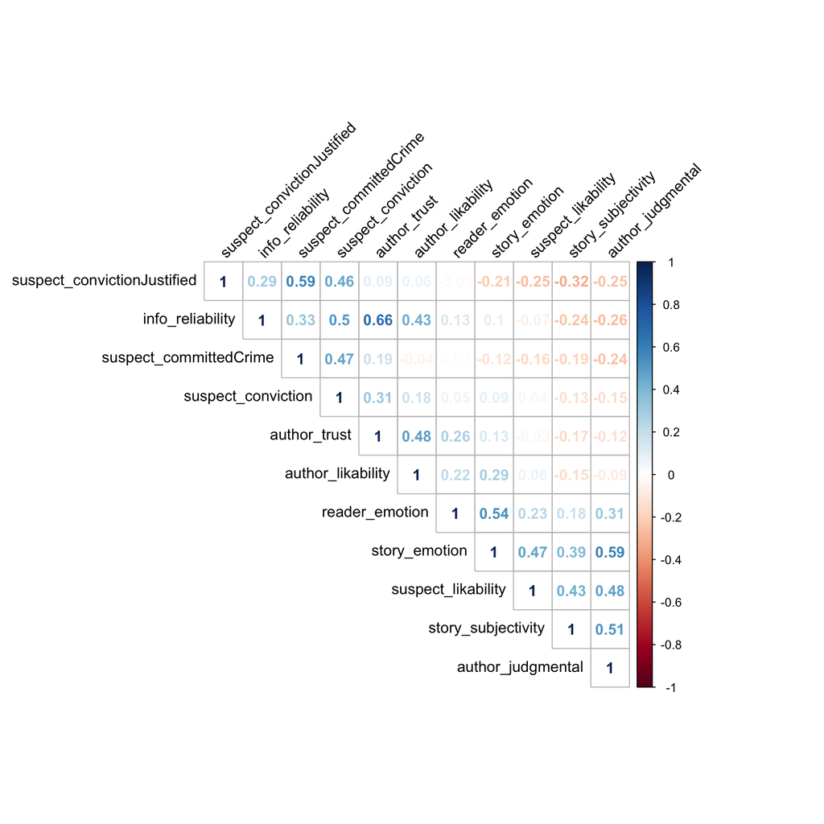

Strongest correlations:

- info_reliability (*“How reliable do you consider the presented information to be?”*) and author_trust (*“How much do you trust the author?”*): 0.66
- story_emotion (*“How emotionally is the story told?”*) and author_judgmental (*“How judgmental is the author?”*): 0.59
- suspect_convictionJustified (*“How justified would a conviction of the suspect(s), i.e., the person/people underlined in the story, be?”*) and suspect_committedCrime (*“How likely is it that the suspect is / the suspects are guilty? (i.e., the person/people underlined in the story)”*): 0.59
- reader_emotion (*“How affected do you feel by the story?”*) and story_emotion (*“How emotionally is the story told?”*): 0.54
- story_subjectivity (*“How objectively / subjectively written is the story?”*) and author_judgmental (*“How judgmental is the author?”*): 0.51

Story_emotion and author_judgmental each correlate with eacher other and one more question (story_emotion: reader_emotion; author_judgmental: story_subjectivity.)

## Qualitative results of two reproductions (each generation 1)

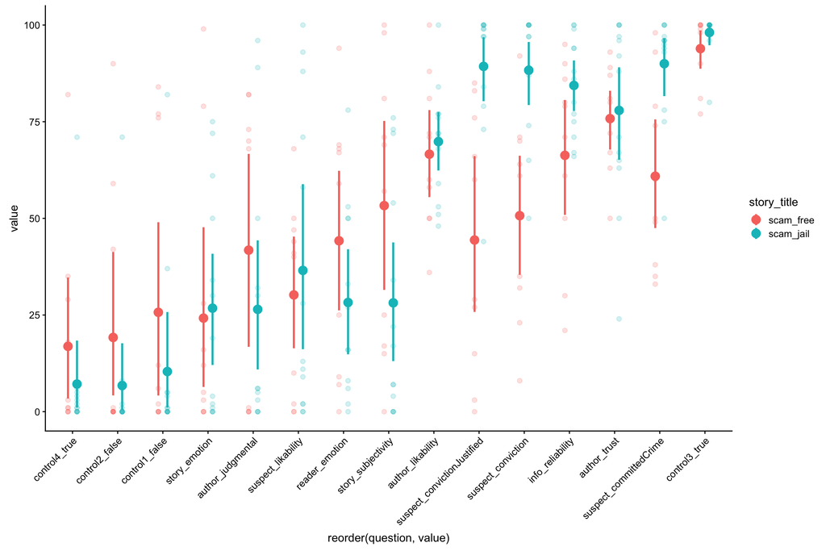